# R Notebook

# Initial Stuff

Load in Initial Processing file (and dependencies)

```r
source("InitialProcessing.R")
```

```
* `` -> ...1

* `` -> ...1




extract_numeric() is deprecated: please use readr::parse_number() instead
```

```r
source("ChesapeakePersonalLibrary.R")
```

# Cells/mg of particle

```r
# my_sizes <- sort(unique(microbialAbundance$Size_Class))
# my_sizes
```

```r
# scientific_10_c <- function(x) {
#     xout <- gsub("1e", "10^{", format(x),fixed=TRUE)
#     xout <- gsub("{-0", "{-", xout,fixed=TRUE)
#     xout <- gsub("{+", "{", xout,fixed=TRUE)
#     xout <- gsub("{0", "{", xout,fixed=TRUE)
#     xout <- paste(xout,"}",sep="")
#     return(parse(text=xout))
#
# }
#
# scale_y_log10nice <- function(name=NULL,omag=seq(-10,20),...) {
#     breaks10 <- 10^omag
#     scale_y_log10(breaks=breaks10,labels=scientific_10_c(breaks10),...)
# } # Reclocated to ChesapeakePersonalLibrary.R
```

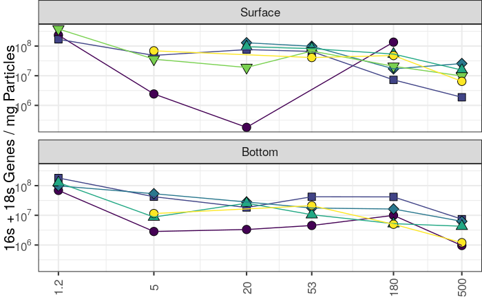

```r
abunPlot <- microbialAbundance %>%
  filter(is.finite(MassperLiter)) %>%
  filter(Depth %in% c("Surface", "Bottom")) %>%
  mutate(copiesPerMg = copiesPerL / MassperLiter) %>%
  ggplot(aes(x = Size_Class, y = copiesPerMg, shape = as.factor(Station), fill = as.factor(Station))) +
  facet_wrap(~Depth, ncol = 1) +
  theme_bw(base_size = 16) +
  geom_point(size = 4) +
  #geom_path() +
  geom_path(aes(color = as.factor(Station))) +
  scale_x_log10(breaks = my_sizes, labels = as.character(my_sizes)) +
  scale_y_log10nice() +
  scale_shape_manual(values = rep(21:25, 2)) +
  scale_fill_viridis_d() +
  scale_color_viridis_d() +
  labs(y = "16s + 18s Genes / mg Particles", x = expression(paste("Particle Size (", mu, "m)"))) +
  theme(legend.position = "none",
        plot.margin = unit(c(0, 0, 0, 0), "cm"),
        axis.title.x = element_blank(),
        axis.text.x = element_text(angle = 90, vjust = .5),
        axis.title.y = element_text(margin = unit(c(0, 0, 0, 0), "mm"), vjust = 0))
abunPlot
```

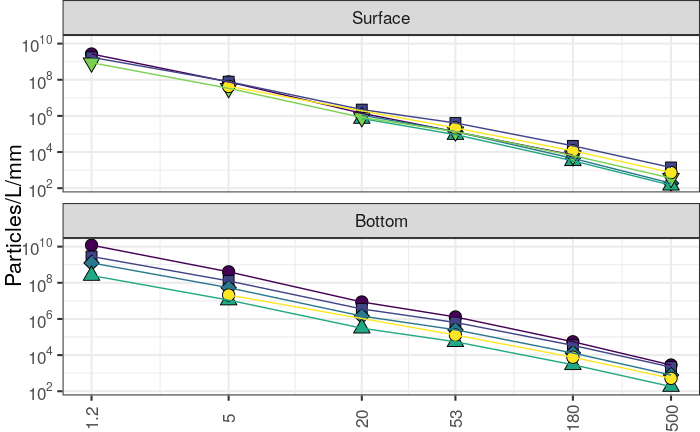

```r
PPLPlot <- microbialAbundance %>%
  filter(Size_Class >= 1) %>%
  filter(Depth %in% c("Surface", "Bottom")) %>%
  ggplot(aes(x = Size_Class, y = ParticlesPerLiter, shape = as.factor(Station), fill = as.factor(Station))) +
  facet_wrap(~Depth, ncol = 1) +
  theme_bw(base_size = 16) +
  geom_point(size = 4) +
  #geom_path() +
  geom_path(aes(color = as.factor(Station))) +
  scale_x_log10(breaks = my_sizes, labels = as.character(my_sizes)) +
  scale_y_log10nice(omag=seq(-10,20, by = 2)) +
  scale_shape_manual(values = rep(21:25, 2)) +
  scale_fill_viridis_d() +
  scale_color_viridis_d() +
  labs(y = "Particles/L/mm", x = expression(paste("Particle Size (", mu, "m)"))) +
  theme(legend.position = "none",
        plot.margin = unit(c(0, 0, 0, 0), "cm"),
        axis.title.x = element_blank(),
        axis.text.x = element_text(angle = 90, vjust = .5),
        axis.title.y = element_text(margin = unit(c(0, 0, 0, 0), "mm"), vjust = 0))
PPLPlot
```

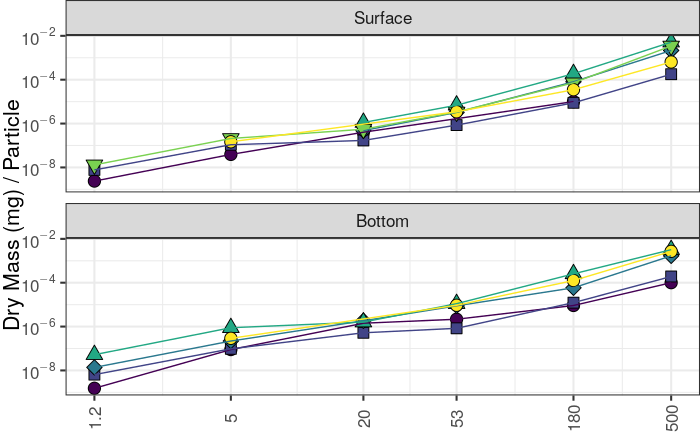

```r
ParticleMassPlot <- microbialAbundance %>%
  filter(Size_Class >= 1) %>%
  filter(Depth %in% c("Surface", "Bottom")) %>%
  ggplot(aes(x = Size_Class, y = MassperLiter/ParticlesPerLiter, shape = as.factor(Station), fill = as.factor(Station))) +
  facet_wrap(~Depth, ncol = 1) +
  theme_bw(base_size = 16) +
  geom_point(size = 4) +
  #geom_path() +
  geom_path(aes(color = as.factor(Station))) +
  scale_x_log10(breaks = my_sizes, labels = as.character(my_sizes)) +
  scale_y_log10nice(omag = seq(-10, 20, by = 2)) +
  scale_shape_manual(values = rep(21:25, 2)) +
  scale_fill_viridis_d() +
  scale_color_viridis_d() +
  labs(y = "Dry Mass (mg) / Particle", x = expression(paste("Particle Size (", mu, "m)"))) +
  theme(legend.position = "none",
        plot.margin = unit(c(0, 0, 0, 0), "cm"),
        axis.title.x = element_blank(),
        axis.text.x = element_text(angle = 90, vjust = .5),
        axis.title.y = element_text(margin = unit(c(0, 0, 0, 0), "mm"), vjust = .5))
ParticleMassPlot
```

# Ibid but combined with data about particles and the CB map

I need to load over data from the CB-Bay project

```r
source("CBMap.R")
```

```r
library(cowplot)
library(grid)
library(gridExtra)
```

```r
x.grob <- textGrob(expression(paste("Particle Size (", mu, "m)")),
                   gp=gpar(fontsize=16))
```

```r
combinedPlot <- plot_grid(PPLPlot, ParticleMassPlot, abunPlot, nrow = 1, labels = c("B", "C", "D"))
```

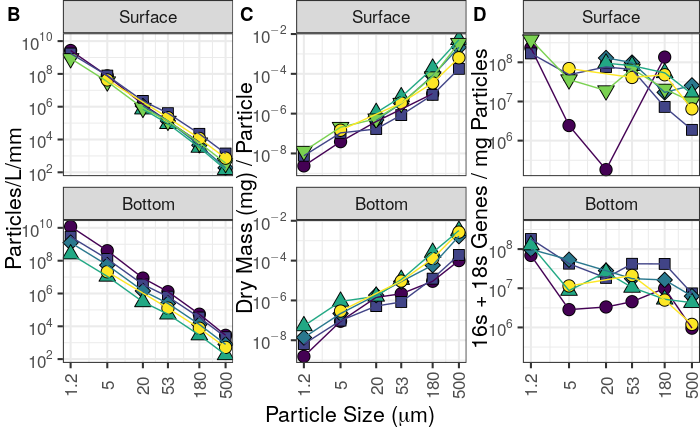

```r
meta2 <- grid.arrange(arrangeGrob(combinedPlot, bottom = x.grob))
```

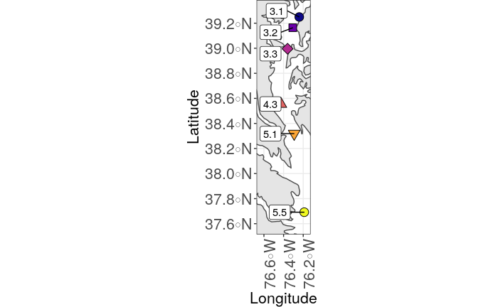

```r
cbMap
```

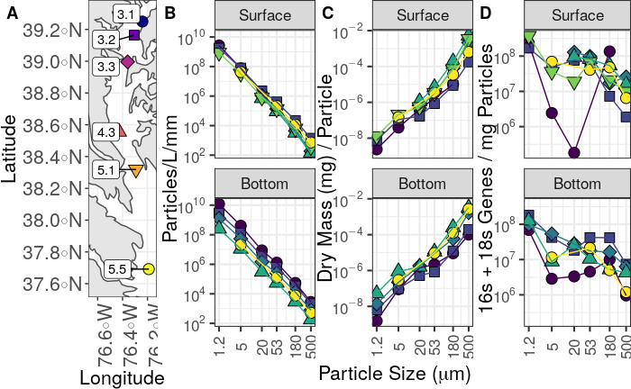

```r
physical_particles <- plot_grid(cbMap, meta2, rel_widths = c(1,3), labels = c("A", ""))
physical_particles
```

```r
ggsave("PhysicalParticles.png", physical_particles, height = 4, width = 7)
```

# Examplar species plot

What are the most abundant ASVs from each cluster? Plot their abundance. Pick the prettiest few and plot

```r
source("ClusteringCore.R")
```

```r
hgroups_exemplars <- cutree(sclust, k = 10)
```

```r
nonSpikes20C <- nonSpikes20 %>% left_join(
  tibble(ASV = names(hgroups_exemplars), cluster = hgroups_exemplars), by = "ASV")
ASVsToView <- nonSpikes20C %>%
  filter(Kingdom == "Bacteria") %>%
  group_by(ASV, cluster) %>%
  summarise(meanCopies = mean(copiesPerL)) %>%
  group_by(cluster) %>%
  summarize(topASV = ASV[which.max(meanCopies)])
```

```r
ASVsToView
```

| cluster | topASV |
| --- | --- |
| 1 | ASV_34 |
| 2 | ASV_3 |
| 3 | ASV_322 |
| 4 | ASV_13 |
| 5 | ASV_20 |
| 6 | ASV_21 |
| 7 | ASV_28 |
| 8 | ASV_54 |
| 9 | ASV_102 |
| 10 | ASV_165 |

```r
nonSpikes20C %>%
  right_join(ASVsToView, by = c("ASV" = "topASV", "cluster")) %>%
  group_by(ASV) %>%
  slice_head()
```

| ASV | reads | ID | Kingdom | Phylum | Class | Order | Family | Genus | nASV | TagLevel | Tag | Station | Size_Class | Depth | Bin_Size | DNAperLiter | MassperLiter | ParticlesPerLiter | Flag | SpikeReads | conversionMultiplier | copiesPerL | hits | freq | cluster |
| --- | --- | --- | --- | --- | --- | --- | --- | --- | --- | --- | --- | --- | --- | --- | --- | --- | --- | --- | --- | --- | --- | --- | --- | --- | --- |
| ASV_102 | 975 | 3-1-B-0-2 | Bacteria | Actinobacteria | Actinobacteria | Frankiales | Sporichthyaceae | hgcI_clade | 102 | Genus | hgcI_clade | 3.1 | 0.2 | Bottom | 1 | 3037.5 | NA | NA | FALSE | 22527 | 13483.82 | 13146723.9 | 22 | 0.3188406 | 9 |
| ASV_13 | 0 | 3-1-B-0-2 | Bacteria | Cyanobacteria | Oxyphotobacteria | Synechococcales | Cyanobiaceae | Cyanobium_PCC-6307 | 13 | Genus | Cyanobium_PCC-6307 | 3.1 | 0.2 | Bottom | 1 | 3037.5 | NA | NA | FALSE | 22527 | 13483.82 | 0.0 | 61 | 0.8840580 | 4 |
| ASV_165 | 5 | 3-1-B-0-2 | Bacteria | Cyanobacteria | Oxyphotobacteria | Synechococcales | Cyanobiaceae | Cyanobium_PCC-6307 | 165 | Genus | Cyanobium_PCC-6307 | 3.1 | 0.2 | Bottom | 1 | 3037.5 | NA | NA | FALSE | 22527 | 13483.82 | 67419.1 | 41 | 0.5942029 | 10 |
| ASV_20 | 0 | 3-1-B-0-2 | Bacteria | Proteobacteria | Gammaproteobacteria | Pseudomonadales | Pseudomonadaceae | Pseudomonas | 20 | Genus | Pseudomonas | 3.1 | 0.2 | Bottom | 1 | 3037.5 | NA | NA | FALSE | 22527 | 13483.82 | 0.0 | 37 | 0.5362319 | 5 |
| ASV_21 | 0 | 3-1-B-0-2 | Bacteria | Lentisphaerae | Oligosphaeria | Oligosphaerales | Lenti-02 | NA | 21 | Family | Lenti-02 | 3.1 | 0.2 | Bottom | 1 | 3037.5 | NA | NA | FALSE | 22527 | 13483.82 | 0.0 | 25 | 0.3623188 | 6 |
| ASV_28 | 624 | 3-1-B-0-2 | Bacteria | Cyanobacteria | Oxyphotobacteria | Synechococcales | Cyanobiaceae | Cyanobium_PCC-6307 | 28 | Genus | Cyanobium_PCC-6307 | 3.1 | 0.2 | Bottom | 1 | 3037.5 | NA | NA | FALSE | 22527 | 13483.82 | 8413903.3 | 67 | 0.9710145 | 7 |
| ASV_3 | 3867 | 3-1-B-0-2 | Bacteria | Proteobacteria | Alphaproteobacteria | SAR11_clade | NA | NA | 3 | Order | SAR11_clade | 3.1 | 0.2 | Bottom | 1 | 3037.5 | NA | NA | FALSE | 22527 | 13483.82 | 52141929.7 | 63 | 0.9130435 | 2 |
| ASV_322 | 0 | 3-1-B-0-2 | Bacteria | Bacteroidetes | Rhodothermia | Balneolales | Balneolaceae | Balneola | 322 | Genus | Balneola | 3.1 | 0.2 | Bottom | 1 | 3037.5 | NA | NA | FALSE | 22527 | 13483.82 | 0.0 | 17 | 0.2463768 | 3 |
| ASV_34 | 0 | 3-1-B-0-2 | Bacteria | Proteobacteria | Alphaproteobacteria | SAR11_clade | Clade_I | Clade_Ia | 34 | Genus | Clade_Ia | 3.1 | 0.2 | Bottom | 1 | 3037.5 | NA | NA | FALSE | 22527 | 13483.82 | 0.0 | 44 | 0.6376812 | 1 |
| ASV_54 | 0 | 3-1-B-0-2 | Bacteria | Bacteroidetes | Bacteroidia | Sphingobacteriales | NS11-12_marine_group | NA | 54 | Family | NS11-12_marine_group | 3.1 | 0.2 | Bottom | 1 | 3037.5 | NA | NA | FALSE | 22527 | 13483.82 | 0.0 | 40 | 0.5797101 | 8 |

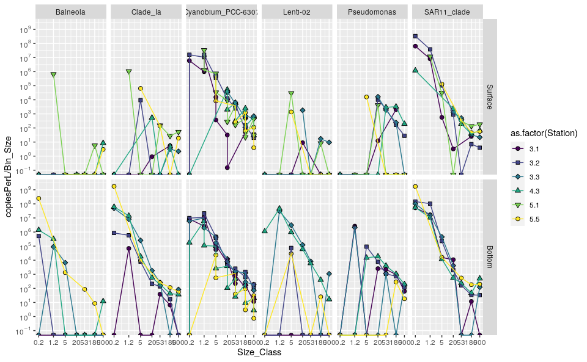

```r
nonSpikes20C %>%
  right_join(ASVsToView, by = c("ASV" = "topASV", "cluster" = "cluster")) %>%
  filter(cluster <= 7, Depth %in% c("Surface", "Bottom"), !is.na(Depth)) %>%
  arrange(Size_Class) %>%
  ggplot(aes(y = copiesPerL/Bin_Size, x = Size_Class, fill = as.factor(Station), shape = as.factor(Station))) +
  scale_y_log10nice() + scale_x_log10(breaks = my_sizes, labels = as.character(my_sizes)) +
  facet_grid(Depth ~ Tag) +
  geom_point(size = 2) +
  geom_path(aes(color = as.factor(Station))) +
  scale_shape_manual(values = rep(21:25, 2)) +
  scale_fill_viridis_d() +
  scale_color_viridis_d()
```

Fig X. Copies per L

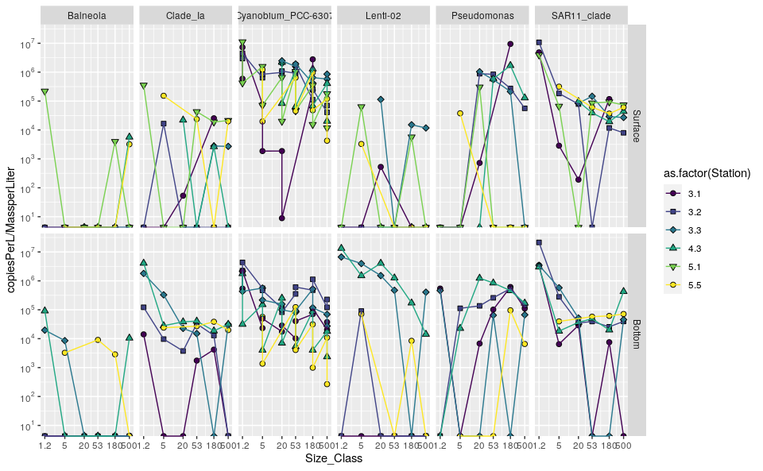

```r
nonSpikes20C %>%
  right_join(ASVsToView, by = c("ASV" = "topASV", "cluster" = "cluster")) %>%
  filter(cluster <= 7, Depth %in% c("Surface", "Bottom"), !is.na(Depth)) %>%
  filter(!is.na(MassperLiter)) %>%
  arrange(Size_Class) %>%
  ggplot(aes(y = copiesPerL/MassperLiter, x = Size_Class, fill = as.factor(Station), shape = as.factor(Station))) +
  scale_y_log10nice() + scale_x_log10(breaks = my_sizes, labels = as.character(my_sizes)) +
  facet_grid(Depth ~ Tag) +
  geom_point(size = 2) +
  geom_path(aes(color = as.factor(Station))) +
  scale_shape_manual(values = rep(21:25, 2)) +
  scale_fill_viridis_d() +
  scale_color_viridis_d()
```

Fig X + 1. Copies per mg stuff. I don’t love these examples because there is a bunch of station to station ariance, and you never see things that like, always show up at large stations.

I wonder if I can find some good examples of consistantly large particle stuff or something.

# What if

I look for things that have high positive slope coefficients between size and normalized copies per L. And select for high mean abundance and high slope. And use site as a random effect? Would be nice to have some things that are intermediately high though. Some sort of polynomial regression?

```r
nest20 <- nonSpikes20 %>%
  select(ASV, Station:ParticlesPerLiter, copiesPerL) %>%
  mutate(Station = as.factor(Station)) %>%
  group_by(ASV) %>%
  nest()
```

```r
TestSub <- nest20[[2]][[1]] %>% ungroup()
TestSub
```

| Station | Size_Class | Depth | Bin_Size | DNAperLiter | MassperLiter | ParticlesPerLiter | copiesPerL |
| --- | --- | --- | --- | --- | --- | --- | --- |
| 3.1 | 0.2 | Bottom | 1.0 | 3.037500e+03 | NA | NA | 2.089992e+06 |
| 3.1 | 1.2 | Bottom | 3.8 | 4.791667e+03 | 18.50000000 | 1.205105e+10 | 4.494636e+07 |
| 3.1 | 180.0 | Bottom | 320.0 | 7.961905e+01 | 0.50011429 | 5.462835e+04 | 1.604530e+05 |
| 3.1 | 20.0 | Bottom | 33.0 | 1.681027e+02 | 12.35092500 | 8.675916e+06 | 3.885019e+05 |
| 3.1 | 5.0 | Bottom | 15.0 | 2.191622e+03 | 36.18518919 | 4.045780e+08 | 2.434777e+06 |
| 3.1 | 500.0 | Bottom | 500.0 | 1.100794e+01 | 0.28228571 | 2.812675e+03 | 1.411274e+04 |
| 3.1 | 53.0 | Bottom | 127.0 | 2.040000e+02 | 2.78614286 | 1.287665e+06 | 1.686419e+05 |
| 3.1 | 0.2 | Surface | 1.0 | 3.690476e+03 | NA | NA | 1.116916e+06 |
| 3.1 | 1.2 | Surface | 3.8 | 3.478723e+03 | 6.34000000 | 2.665037e+09 | 1.834433e+07 |
| 3.1 | 180.0 | Surface | 320.0 | 3.044156e+01 | 0.06857143 | 6.839000e+03 | 6.796430e+04 |

[output cut: 59 more lines]

```r
library(lme4)
library(broom)
library(broom.mixed)
```

```r
lm(log(copiesPerL/Bin_Size) ~ log(Size_Class), data = TestSub) %>% tidy()
```

| term | estimate | std.error | statistic | p.value |
| --- | --- | --- | --- | --- |
| (Intercept) | 14.731869 | 0.34536647 | 42.65576 | 2.715184e-50 |
| log(Size_Class) | -1.421137 | 0.08855539 | -16.04800 | 1.207735e-24 |

```r
lmer(log(copiesPerL/Bin_Size) ~ log(Size_Class) + (Size_Class|Station) + (Size_Class|Depth) , data = TestSub %>%
       mutate(as.factor(Station))) %>% AIC()
```

```
boundary (singular) fit: see ?isSingular
```

```
[1] 294.8901
```

```r
lmer(log(copiesPerL/Bin_Size) ~ log(Size_Class) + (1|Station) + (1|Depth) , data = TestSub %>%
       mutate(as.factor(Station))) %>% AIC() # Better
```

```
[1] 284.1189
```

```r
modDf <- nest20 %>%
  mutate(mod = map(data,
                   ~lmer(log((copiesPerL+1)/Bin_Size) ~ log(Size_Class) +
                           (Size_Class|Station) + (Size_Class|Depth), data = .)
  )
  )
```

[output not shown]

[output cut: 662 more lines]

[output not shown]

```r
modDf01 <- modDf %>%
  mutate(tidied = map(mod, tidy)) %>%
  unnest(tidied) %>%
  select(-data, -mod)
```

```r
modDf02 <- modDf01 %>%
  filter(term == "log(Size_Class)") %>%
  select(ASV, estimate, std.error)
```

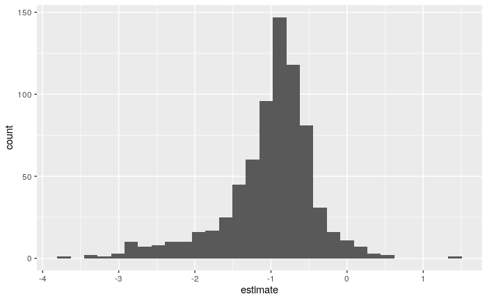

```r
modDf02 %>%
  ggplot(aes(x = estimate)) + geom_histogram() +
  scale_x_continuous(breaks = seq(from = -4, to = 2, by = 1))
```

There are some things that are ore abundant in the large particles

So Many ASVs. How do I ID the ones I want?

I kind of want to look at average concentrations (or sums)

```r
SlopesAndMeans <- nonSpikes20 %>%
  #filter(Kingdom == "Bacteria") %>%
  group_by(ASV) %>%
  summarise(meanCopies = mean(copiesPerL)) %>%
  left_join(modDf02, by = "ASV")
SlopesAndMeans %>% head()
```

| ASV | meanCopies | estimate | std.error |
| --- | --- | --- | --- |
| ASV_10 | 32238585.13 | -2.3501671 | 0.2456952 |
| ASV_100 | 2734045.60 | -2.7819605 | 0.3352186 |
| ASV_1003 | 24489.66 | -0.9335487 | 0.2130121 |
| ASV_1006 | 10742.81 | -0.3404084 | 0.2260665 |
| ASV_101 | 612743.05 | -0.1679944 | 0.2937289 |
| ASV_1010 | 32403.89 | -0.6419482 | 0.1757712 |

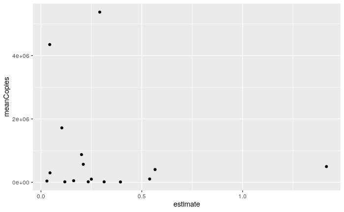

```r
SlopesAndMeans %>%
  filter(estimate >= 0) %>%
  ggplot(aes(x = estimate, y = meanCopies, label = ASV)) +
  geom_point() +
  geom_label_repel()
```

ASV 13 looks promising

```r
taxa %>%
  filter(ASV %in% c("ASV_13", "ASV_23", "ASV_58"))
```

| ASV | Kingdom | Phylum | Class | Order | Family | Genus | nASV | TagLevel | Tag |
| --- | --- | --- | --- | --- | --- | --- | --- | --- | --- |
| ASV_13 | Bacteria | Cyanobacteria | Oxyphotobacteria | Synechococcales | Cyanobiaceae | Cyanobium_PCC-6307 | 13 | Genus | Cyanobium_PCC-6307 |
| ASV_23 | Bacteria | Cyanobacteria | Oxyphotobacteria | Synechococcales | Cyanobiaceae | Synechococcus_CC9902 | 23 | Genus | Synechococcus_CC9902 |
| ASV_58 | Bacteria | Cyanobacteria | Oxyphotobacteria | Synechococcales | Cyanobiaceae | Cyanobium_PCC-6307 | 58 | Genus | Cyanobium_PCC-6307 |

The big stuff are all cyanos! Huh.

```r
Targets <- SlopesAndMeans %>% filter(estimate > 0, meanCopies > 1e5) %>% pull(ASV)
taxa %>%
  filter(ASV %in% Targets)
```

| ASV | Kingdom | Phylum | Class | Order | Family | Genus | nASV | TagLevel | Tag |
| --- | --- | --- | --- | --- | --- | --- | --- | --- | --- |
| ASV_7 | Eukaryota | Arthropoda | Arachnida | NA | NA | NA | 7 | Class | Arachnida |
| ASV_13 | Bacteria | Cyanobacteria | Oxyphotobacteria | Synechococcales | Cyanobiaceae | Cyanobium_PCC-6307 | 13 | Genus | Cyanobium_PCC-6307 |
| ASV_20 | Bacteria | Proteobacteria | Gammaproteobacteria | Pseudomonadales | Pseudomonadaceae | Pseudomonas | 20 | Genus | Pseudomonas |
| ASV_23 | Bacteria | Cyanobacteria | Oxyphotobacteria | Synechococcales | Cyanobiaceae | Synechococcus_CC9902 | 23 | Genus | Synechococcus_CC9902 |
| ASV_56 | Bacteria | Cyanobacteria | Oxyphotobacteria | Nostocales | Microcystaceae | Synechocystis_PCC-6803 | 56 | Genus | Synechocystis_PCC-6803 |
| ASV_58 | Bacteria | Cyanobacteria | Oxyphotobacteria | Synechococcales | Cyanobiaceae | Cyanobium_PCC-6307 | 58 | Genus | Cyanobium_PCC-6307 |
| ASV_71 | Bacteria | Proteobacteria | Gammaproteobacteria | Pseudomonadales | Pseudomonadaceae | Pseudomonas | 71 | Genus | Pseudomonas |
| ASV_82 | Bacteria | Planctomycetes | Planctomycetacia | Pirellulales | Pirellulaceae | Blastopirellula | 82 | Genus | Blastopirellula |
| ASV_299 | Bacteria | Planctomycetes | Planctomycetacia | Pirellulales | Pirellulaceae | NA | 299 | Family | Pirellulaceae |

```r
Horses <- SlopesAndMeans %>%
  left_join(taxa, by = "ASV") %>%
  filter(estimate > 0, meanCopies > 0e5) %>%
  arrange(-meanCopies)
Horses
```

| ASV | meanCopies | estimate | std.error | Kingdom | Phylum | Class | Order | Family | Genus | nASV | TagLevel | Tag |
| --- | --- | --- | --- | --- | --- | --- | --- | --- | --- | --- | --- | --- |
| ASV_13 | 5374188.61 | 0.29147460 | 0.2861694 | Bacteria | Cyanobacteria | Oxyphotobacteria | Synechococcales | Cyanobiaceae | Cyanobium_PCC-6307 | 13 | Genus | Cyanobium_PCC-6307 |
| ASV_23 | 4348326.10 | 0.04336717 | 0.2715367 | Bacteria | Cyanobacteria | Oxyphotobacteria | Synechococcales | Cyanobiaceae | Synechococcus_CC9902 | 23 | Genus | Synechococcus_CC9902 |
| ASV_58 | 1718999.37 | 0.10330597 | 0.2968209 | Bacteria | Cyanobacteria | Oxyphotobacteria | Synechococcales | Cyanobiaceae | Cyanobium_PCC-6307 | 58 | Genus | Cyanobium_PCC-6307 |
| ASV_56 | 874489.21 | 0.20094899 | 0.3290473 | Bacteria | Cyanobacteria | Oxyphotobacteria | Nostocales | Microcystaceae | Synechocystis_PCC-6803 | 56 | Genus | Synechocystis_PCC-6803 |
| ASV_82 | 567870.16 | 0.20989558 | 0.2939647 | Bacteria | Planctomycetes | Planctomycetacia | Pirellulales | Pirellulaceae | Blastopirellula | 82 | Genus | Blastopirellula |
| ASV_7 | 496592.80 | 1.41594963 | 0.3039250 | Eukaryota | Arthropoda | Arachnida | NA | NA | NA | 7 | Class | Arachnida |
| ASV_20 | 403203.23 | 0.56595782 | 0.3261862 | Bacteria | Proteobacteria | Gammaproteobacteria | Pseudomonadales | Pseudomonadaceae | Pseudomonas | 20 | Genus | Pseudomonas |
| ASV_299 | 297565.11 | 0.04464960 | 0.2812254 | Bacteria | Planctomycetes | Planctomycetacia | Pirellulales | Pirellulaceae | NA | 299 | Family | Pirellulaceae |
| ASV_71 | 104054.06 | 0.53897912 | 0.2731060 | Bacteria | Proteobacteria | Gammaproteobacteria | Pseudomonadales | Pseudomonadaceae | Pseudomonas | 71 | Genus | Pseudomonas |
| ASV_153 | 98978.08 | 0.24986727 | 0.2965480 | Bacteria | Cyanobacteria | Oxyphotobacteria | Chloroplast | NA | NA | 153 | Order | Chloroplast |

[output cut: 6 more lines]

Ok. Big stuff are cyanos and Planctomycetes, and apparently Spiders. Also apparently some proteos of different stripes. Rhodobacter are cool though.

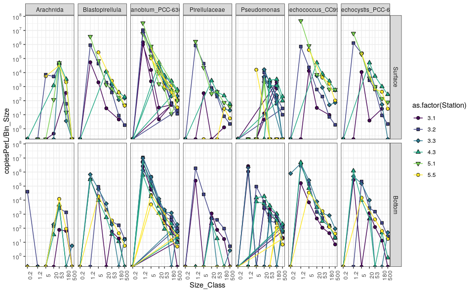

```r
nonSpikes20 %>%
  left_join(SlopesAndMeans, by = "ASV") %>%
  filter(estimate > 0, meanCopies > 1e5, Depth != "Oxy") %>%
  arrange(-meanCopies, Size_Class) %>%
  ggplot(aes(y = copiesPerL/Bin_Size, x = Size_Class, fill = as.factor(Station), shape = as.factor(Station))) +
  scale_y_log10nice() + scale_x_log10(breaks = my_sizes, labels = as.character(my_sizes)) +
  facet_grid(Depth ~ Tag) +
  geom_point(size = 2) +
  geom_path(aes(color = as.factor(Station))) +
  scale_shape_manual(values = rep(21:25, 2)) +
  scale_fill_viridis_d() +
  scale_color_viridis_d() +
  theme_bw() +
  theme(axis.text.x = element_text(angle = 90))
```

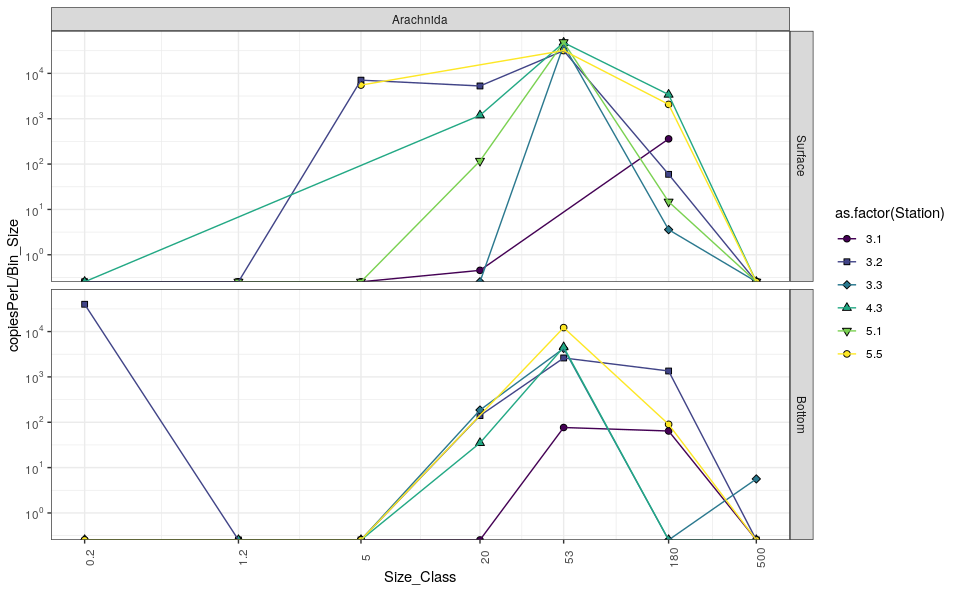

```r
nonSpikes20 %>%
  left_join(SlopesAndMeans, by = "ASV") %>%
  filter(estimate > 0, meanCopies > 1e5, Depth != "Oxy") %>%
  arrange(-meanCopies, Size_Class) %>%
  filter(ASV == "ASV_7") %>%
  ggplot(aes(y = copiesPerL/Bin_Size, x = Size_Class, fill = as.factor(Station), shape = as.factor(Station))) +
  scale_y_log10nice() + scale_x_log10(breaks = my_sizes, labels = as.character(my_sizes)) +
  facet_grid(Depth ~ Tag) +
  geom_point(size = 2) +
  geom_path(aes(color = as.factor(Station))) +
  scale_shape_manual(values = rep(21:25, 2)) +
  scale_fill_viridis_d() +
  scale_color_viridis_d() +
  theme_bw() +
  theme(axis.text.x = element_text(angle = 90))
```

```r
nonSpikes20 %>%
  left_join(SlopesAndMeans, by = "ASV") %>%
  filter(estimate > 0, meanCopies > 1e5, Depth != "Oxy") %>%
  arrange(-meanCopies, Size_Class) %>%
  filter(ASV = "ASV_7") %>%
  ggplot(aes(y = copiesPerL/Bin_Size, x = Size_Class, fill = as.factor(Station), shape = as.factor(Station))) +
  scale_y_log10nice() + scale_x_log10(breaks = my_sizes, labels = as.character(my_sizes)) +
  facet_grid(Depth ~ Tag) +
  geom_point(size = 2) +
  geom_path(aes(color = as.factor(Station))) +
  scale_shape_manual(values = rep(21:25, 2)) +
  scale_fill_viridis_d() +
  scale_color_viridis_d() +
  theme_bw() +
  theme(axis.text.x = element_text(angle = 90))
```

```
Error: Problem with `filter()` input `..1`.
x Input `..1` is named.
ℹ This usually means that you've used `=` instead of `==`.
ℹ Did you mean `ASV == "ASV_7"`?
Run `rlang::last_error()` to see where the error occurred.
```

Lets look at these!

I like, as examples Paracoccus (a Rhodobacter) -ASV_459 Synechococcus_CC9902 – ASV_23 SAR11_Clade – ASV_3

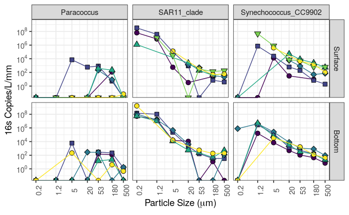

```r
nonSpikes20 %>%
  filter(ASV %in% c("ASV_3", "ASV_23", "ASV_459"), Depth != "Oxy") %>%
  arrange(Size_Class) %>%
  ggplot(aes(y = copiesPerL/Bin_Size, x = Size_Class, fill = as.factor(Station), shape = as.factor(Station))) +
  scale_y_log10nice(omag = seq(-10, 20, by = 2)) + scale_x_log10(breaks = my_sizes, labels = as.character(my_sizes)) +
  facet_grid(Depth ~ Tag) +
  geom_point(size = 3) +
  geom_path(aes(color = as.factor(Station))) +
  scale_shape_manual(values = rep(21:25, 2)) +
  scale_fill_viridis_d() +
  scale_color_viridis_d() +
  theme_bw(base_size = 14) +
  theme(axis.text.x = element_text(angle = 90), legend.position = "none") +
  labs(y = "16s Copies/L/mm", x = expression(paste("Particle Size (", mu, "m)")), fill = "Station", color = "Station", shape = "Station")
```

# Module abundance plot

```r
hgroups_ants <- cutree(sclust, k = 50)
```

```r
nonSpikes20A <- nonSpikes20 %>% left_join(
  tibble(ASV = names(hgroups_ants), cluster = hgroups_ants), by = "ASV")
# ASVsToView <- nonSpikes20A %>%
#   filter(Kingdom == "Bacteria") %>%
#   group_by(ASV, cluster) %>%
#   summarise(meanCopies = mean(copiesPerL)) %>%
#   group_by(cluster) %>%
#   summarize(topASV = ASV[which.max(meanCopies)])
```

```r
ClusterSumsA <- nonSpikes20A %>%
  group_by(Station, Depth, cluster, Size_Class, Bin_Size) %>%
  summarise(copiesPerL = sum(copiesPerL))
```

```r
HugeSurfacePlot <- nonSpikes20A %>%
  filter(Depth == "Surface") %>%
  arrange(Bin_Size) %>%
  ggplot(aes(y = copiesPerL/Bin_Size, x = Size_Class)) +
  facet_grid(cluster ~ Station) +
  scale_y_log10nice(omag = seq(-10, 20, by = 4)) + scale_x_log10(breaks = my_sizes, labels = as.character(my_sizes)) +
  geom_path(alpha = 0.5, aes(group = ASV)) +
  theme_bw(base_size = 14) +
  theme(axis.text.x = element_text(angle = 90), legend.position = "none") +
  labs(y = "16s Copies/L/mm", x = expression(paste("Particle Size (", mu, "m)")), fill = "Station", color = "Station", shape = "Station") +
  geom_path(color = "red", data = ClusterSumsA %>% filter(Depth == "Surface")) # Add sums
ggsave("HugeSurfacePlot.pdf", HugeSurfacePlot, height = 72, width = 8, limitsize = FALSE)
```

I think we’re using “intercept” in the clustering information somehow. Which I don’t particularly want. But the clustering does happen by correlation. Super strange. Maybe the correlation isn’t the way I think it is?

```r
MinimalSurfacePlot <- nonSpikes20A %>%
  filter(Depth == "Surface", cluster %in% c(1, 7, 15)) %>%
  arrange(Bin_Size) %>%
  ggplot(aes(y = copiesPerL/Bin_Size, x = Size_Class)) +
  facet_grid(cluster~ Station) +
  scale_y_log10nice(omag = seq(-10, 20, by = 2)) + scale_x_log10(breaks = my_sizes, labels = as.character(my_sizes)) +
  geom_path(alpha = 0.5, aes(group = ASV)) +
  theme_bw(base_size = 14) +
  theme(axis.text.x = element_text(angle = 90), legend.position = "none") +
  labs(y = "16s Copies/L/mm", x = expression(paste("Particle Size (", mu, "m)")), fill = "Station", color = "Station", shape = "Station") +
  geom_path(color = "red", data = ClusterSumsA %>% filter(Depth == "Surface", cluster %in% c(1, 7, 15))) # Add sums
ggsave("MinimalSurfacePlot.pdf", MinimalSurfacePlot, height = 11, width = 8, limitsize = FALSE)
```

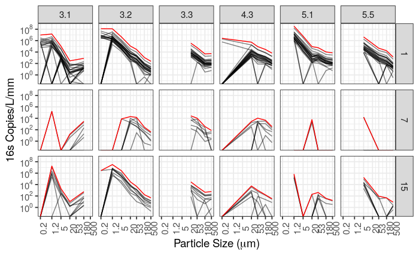

```r
MinimalSurfacePlot
```

```r
MinimalClusterPlot <- nonSpikes20A %>%
  filter(Depth != "Oxy", cluster %in% c(1, 7, 15)) %>%
  arrange(Bin_Size) %>%
  ggplot(aes(y = copiesPerL/Bin_Size, x = Size_Class)) +
  facet_grid(cluster + Depth ~ Station) +
  scale_y_log10nice(omag = seq(-10, 20, by = 2)) + scale_x_log10(breaks = my_sizes, labels = as.character(my_sizes)) +
  geom_path(alpha = 0.5, aes(group = ASV)) +
  theme_bw(base_size = 14) +
  theme(axis.text.x = element_text(angle = 90), legend.position = "none") +
  labs(y = "16s Copies/L/mm", x = expression(paste("Particle Size (", mu, "m)")), fill = "Station", color = "Station", shape = "Station") +
  geom_path(color = "red", data = ClusterSumsA %>% filter(Depth != "Oxy", cluster %in% c(1, 7, 15))) # Add sums
ggsave("MinimalClusterPlot.pdf", MinimalClusterPlot, height = 11, width = 8, limitsize = FALSE)
```

# For sairah specifically

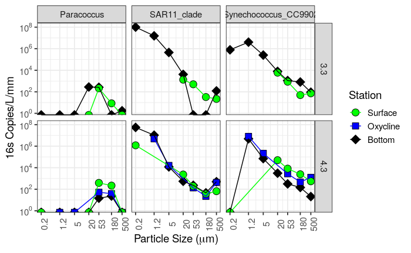

```r
ExampleTaxa <- nonSpikes20 %>%
  filter(ASV %in% c("ASV_3", "ASV_23", "ASV_459")) %>%
  filter(Station %in% c("3.3", "4.3")) %>%
  mutate(Depth = recode(Depth, Oxy = "Oxycline")) %>%
  arrange(Size_Class) %>%
  ggplot(aes(y = copiesPerL/Bin_Size, x = Size_Class, fill = as.factor(Depth), shape = as.factor(Depth))) +
  scale_y_log10nice(omag = seq(-10, 20, by = 2)) + scale_x_log10(breaks = my_sizes, labels = as.character(my_sizes)) +
  facet_grid(Station ~ Tag) +
  geom_point(size = 4) +
  geom_path(aes(color = as.factor(Depth))) +
  scale_shape_manual(values = rep(21:25, 2)) +
  scale_fill_manual(values = c("green", "blue", "black")) +
  scale_color_manual(values = c("green", "blue", "black")) +
  theme_bw(base_size = 14) +
  theme(axis.text.x = element_text(angle = 90), legend.position = "right") +
  labs(y = "16s Copies/L/mm", x = expression(paste("Particle Size (", mu, "m)")), fill = "Station", color = "Station", shape = "Station")
ExampleTaxa
```

### Thing 2

```r
abunPlot0 <- microbialAbundance %>%
  filter(is.finite(MassperLiter)) %>%
  #filter(Depth %in% c("Surface", "Bottom")) %>%
  filter(Station %in% c(3.3, 4.3)) %>%
  mutate(Depth = recode(Depth, Oxy = "Oxycline")) %>%
  mutate(copiesPerMg = copiesPerL / MassperLiter) %>%
  ggplot(aes(x = Size_Class, y = copiesPerMg, shape = as.factor(Depth), fill = as.factor(Depth))) +
  facet_wrap(~Station, ncol = 1) +
  theme_bw(base_size = 16) +
  geom_point(size = 4) +
  #geom_path() +
  geom_path(aes(color = as.factor(Depth))) +
  scale_x_log10(breaks = my_sizes, labels = as.character(my_sizes)) +
  scale_y_log10nice() +
  scale_shape_manual(values = rep(21:25, 2)) +
  scale_fill_manual(values = c("green", "blue", "black")) +
  scale_color_manual(values = c("green", "blue", "black")) +
  labs(y = "16s + 18s Genes / mg Particles", x = expression(paste("Particle Size (", mu, "m)")), color = "Depth", fill = "Depth", shape = "Depth") +
  theme(plot.margin = unit(c(0, 0, 0, 0), "cm"),
        axis.title.x = element_blank(),
        axis.text.x = element_text(angle = 90, vjust = .5),
        axis.title.y = element_text(margin = unit(c(0, 0, 0, 0), "mm"), vjust = 0))
SairahLegend <- get_legend(abunPlot0)
abunPlot <- abunPlot0 + theme(legend.position = "none")
#abunPlot
```

```r
PPLPlot <- microbialAbundance %>%
  filter(Size_Class >= 1) %>%
  #filter(Depth %in% c("Surface", "Bottom")) %>%
  filter(Station %in% c(3.3, 4.3)) %>%
  ggplot(aes(x = Size_Class, y = ParticlesPerLiter, shape = as.factor(Depth), fill = as.factor(Depth))) +
  facet_wrap(~Station, ncol = 1) +
  theme_bw(base_size = 16) +
  geom_point(size = 4) +
  #geom_path() +
  geom_path(aes(color = as.factor(Depth))) +
  scale_x_log10(breaks = my_sizes, labels = as.character(my_sizes)) +
  scale_y_log10nice(omag=seq(-10,20, by = 2)) +
  scale_shape_manual(values = rep(21:25, 2)) +
  scale_fill_manual(values = c("green", "blue", "black")) +
  scale_color_manual(values = c("green", "blue", "black")) +
  labs(y = "Particles/L/mm", x = expression(paste("Particle Size (", mu, "m)"))) +
  theme(legend.position = "none",
        plot.margin = unit(c(0, 0, 0, 0), "cm"),
        axis.title.x = element_blank(),
        axis.text.x = element_text(angle = 90, vjust = .5),
        axis.title.y = element_text(margin = unit(c(0, 0, 0, 0), "mm"), vjust = 0))
#PPLPlot
```

```r
ParticleMassPlot <- microbialAbundance %>%
  filter(Size_Class >= 1) %>%
  #filter(Depth %in% c("Surface", "Bottom")) %>%
  filter(Station %in% c(3.3, 4.3)) %>%
  ggplot(aes(x = Size_Class, y = MassperLiter/ParticlesPerLiter, shape = as.factor(Depth), fill = as.factor(Depth))) +
  facet_wrap(~Station, ncol = 1) +
  theme_bw(base_size = 16) +
  geom_point(size = 4) +
  #geom_path() +
  geom_path(aes(color = as.factor(Depth))) +
  scale_x_log10(breaks = my_sizes, labels = as.character(my_sizes)) +
  scale_y_log10nice(omag = seq(-10, 20, by = 2)) +
  scale_shape_manual(values = rep(21:25, 2)) +
  scale_fill_manual(values = c("green", "blue", "black")) +
  scale_color_manual(values = c("green", "blue", "black")) +
  labs(y = "Dry Mass (mg) / Particle", x = expression(paste("Particle Size (", mu, "m)"))) +
  theme(legend.position = "none",
        plot.margin = unit(c(0, 0, 0, 0), "cm"),
        axis.title.x = element_blank(),
        axis.text.x = element_text(angle = 90, vjust = .5),
        axis.title.y = element_text(margin = unit(c(0, 0, 0, 0), "mm"), vjust = .5))
#ParticleMassPlot
```

```r
x.grob <- textGrob(expression(paste("Particle Size (", mu, "m)")),
                   gp=gpar(fontsize=16))
```

```r
combinedPlot <- plot_grid(PPLPlot, ParticleMassPlot, abunPlot, nrow = 1, labels = c("A", "B", "C"))
```

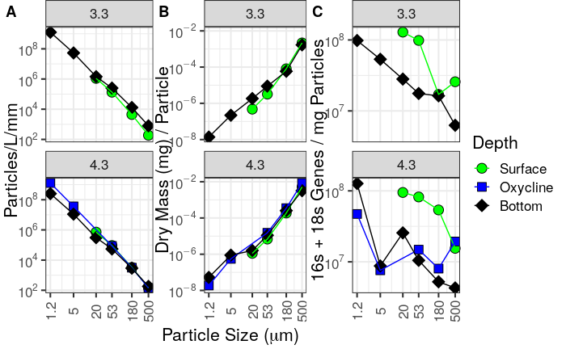

```r
meta2 <- grid.arrange(arrangeGrob(combinedPlot, bottom = x.grob), right = SairahLegend)
```